# Shrimp modeling

## Data:

Data we have at month-year-fishing area resolution:

- Average length and sample size for each age class (1-3) from April to October, i.e., up to 21 observations of each year class in a given area, but some combinations are missing. This is from sampling the catch.
- SD for each age class from 2014-2018 (actually have individual data for each shrimp measured in these years)
- Total catch in lbs
- Count per pound
- Percent age composition of the catch by number
- All of this for 1989-2018, though a lot of pubs seems to have 1980-present

Here is a (different) plot of the mean lengths at age by area and year class.

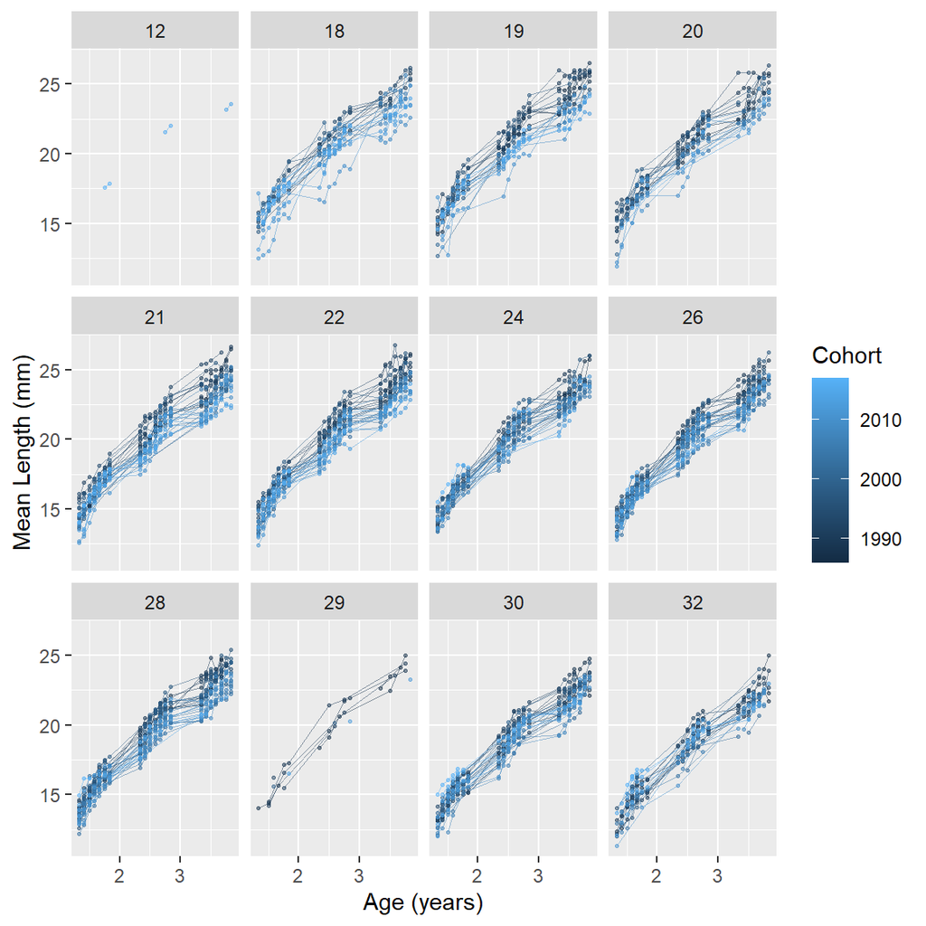

Here is a map of the state areas:

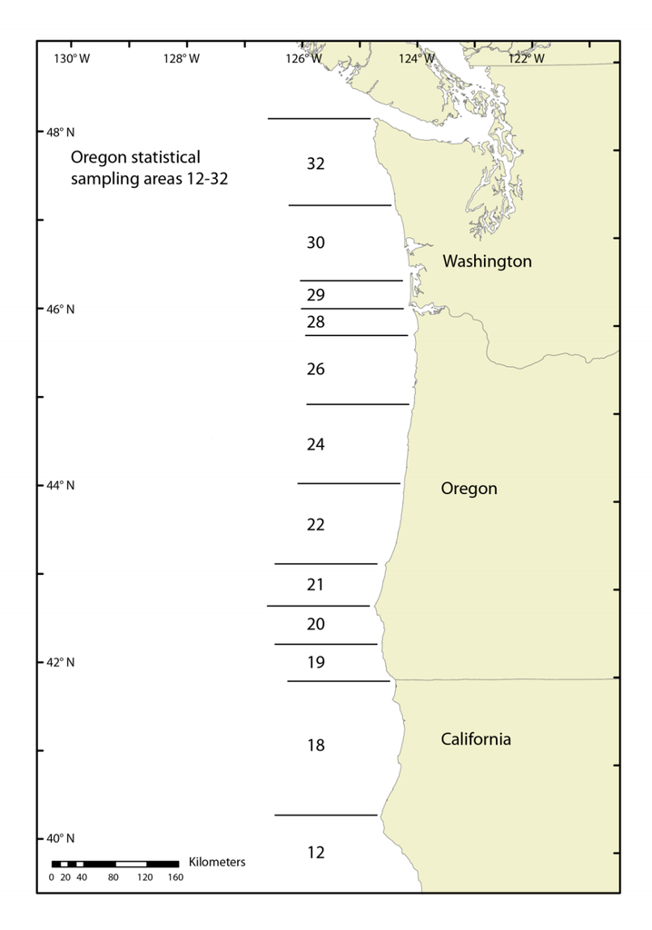

## Model:

$L_{a,y,r}$ is length of age $a$ (in months) shrimp from the cohort $c$ caught in area (region) r, and $m$ is the month of the year (i.e., cycles back to 1 at the end of the year unlike $a$). To align $m$ with the seasonal cycle of growth, $m=1$ corresponds with March.

$$\begin{aligned}
L_{1,c,r} &= \mu_{L1} + \gamma_{r} + \varepsilon_{1,c} \\
L_{a,c,r} &= \alpha_0 + \alpha_1 L_{a-1,c,r} + \alpha_s \sin\left(\tfrac{\pi m}{6}\right) + \varepsilon_{a,c,r} \\
\hat{L}_{a,c,r} &= L_{a,c,r} + \delta_{a,c,r}
\end{aligned}$$

$\mu_{L1}$ is average size of age 1 shrimp in April, $\alpha_0$ and $\alpha_1$ describe the average monthly growth, and $\alpha_s$ is the magnitude of the seasonality component.

Distributional assumptions are:
$$\begin{aligned}
\varepsilon_{1,c} &\sim N(0, \sigma_{L1}) \\
\varepsilon_{a,c} &\sim N(0, \sigma_p), a\neq 1\\
\delta_{a,c,r} &\sim N(0, \sigma_o)\\
\gamma_r &\sim N(0, \sigma_r)
\end{aligned}$$

## Fitting:

The model is fit in Stan as a multivariate autoregressive state-space model. The global mean is subtracted from all lengths to improve numerical stability. Each year class is essentially a different “state”, and each area represents a different observation process of the same state. Three chains are run for 5000 iterations, and the final 2500 iterations of each chain are retained. [More chains fewer iterations?]

# Results:

First, here is a table of the estimated parameters. The mixing for the initial size (not just the mean below, but also the parameters for each year and for the fishing area offsets) is poor, so the model should probably get run longer.

|  | mean | se_mean | sd | 2.5% | 25% | 50% | 75% | 97.5% | n_eff | Rhat |
| --- | --- | --- | --- | --- | --- | --- | --- | --- | --- | --- |
| $\mu_{L1}$ | -5.5179996 | 0.0154278 | 0.2521622 | -6.0107251 | -5.6759714 | -5.5171448 | -5.3619083 | -5.0139409 | 267.1482 | 1.0012981 |
| $\sigma_{L1}$ | 0.5906135 | 0.0010466 | 0.0896690 | 0.4452781 | 0.5272381 | 0.5805736 | 0.6440983 | 0.7993367 | 7339.9949 | 1.0003800 |
| $\sigma_r$ | 0.7329896 | 0.0041433 | 0.1825277 | 0.4736537 | 0.6065812 | 0.6996598 | 0.8217833 | 1.1798252 | 1940.7246 | 1.0034231 |
| $\alpha_s$ | 0.2478452 | 0.0002202 | 0.0145780 | 0.2194285 | 0.2381074 | 0.2479104 | 0.2577450 | 0.2767840 | 4383.8334 | 1.0005649 |
| $\alpha_0$ | 0.3158242 | 0.0001174 | 0.0075475 | 0.3011436 | 0.3107203 | 0.3158028 | 0.3208927 | 0.3306881 | 4134.3207 | 1.0008420 |
| $\alpha_1$ | 0.9986627 | 0.0000107 | 0.0009387 | 0.9964433 | 0.9980925 | 0.9988309 | 0.9994042 | 0.9999418 | 7649.8925 | 1.0001975 |
| $\sigma_p$ | 0.2164861 | 0.0002708 | 0.0101776 | 0.1975685 | 0.2094901 | 0.2162405 | 0.2232422 | 0.2369290 | 1412.8022 | 1.0012565 |
| $\sigma_o$ | 0.5200612 | 0.0000613 | 0.0062354 | 0.5080523 | 0.5158175 | 0.5199736 | 0.5243430 | 0.5323064 | 10335.7700 | 0.9998216 |

Second, here is a plot of residuals versus fitted values (using the median from the posterior as the fitted value) with a smoother. We see that the residuals look alright.

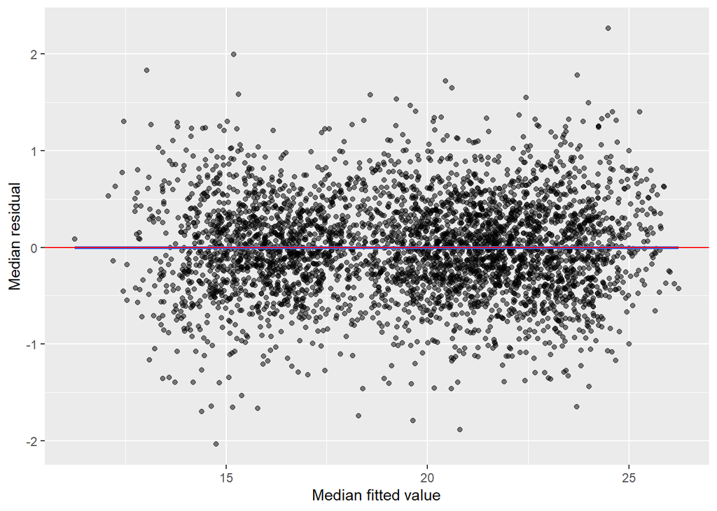

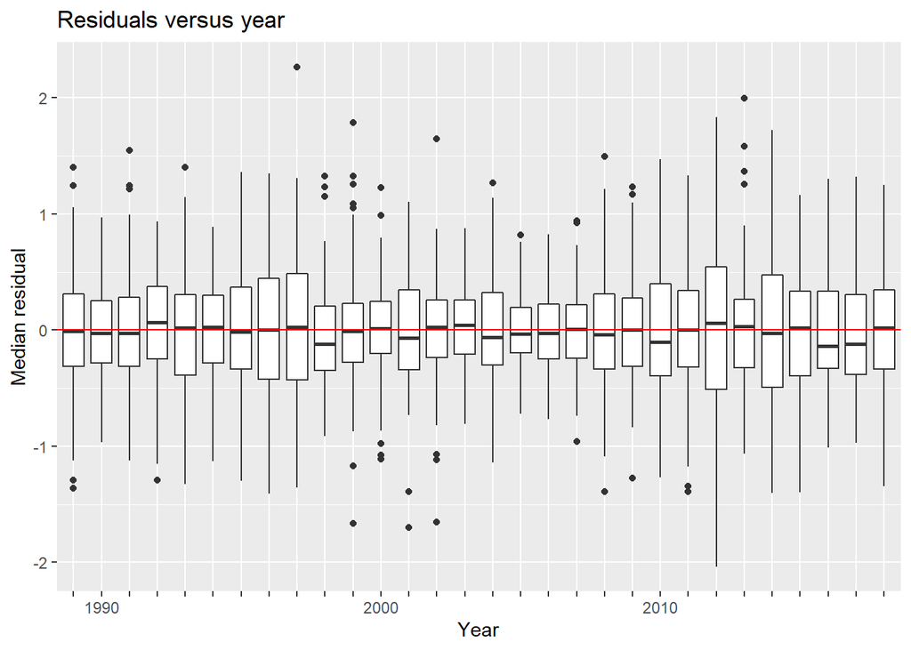

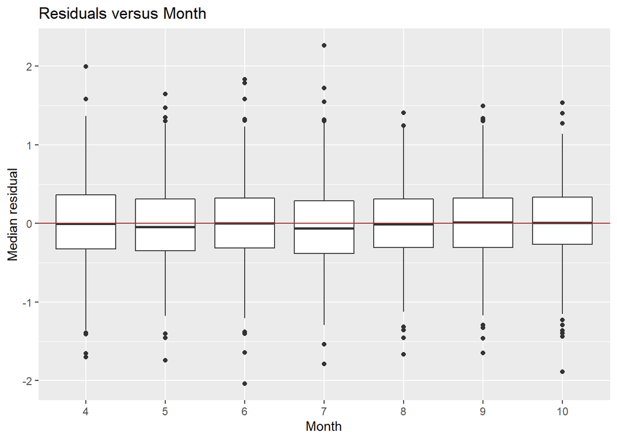

I also thought it would be useful to look at the process errors. We can see that the process model under-estimates growth for age 1 and over-estimates it for age 3. Oddly, $\alpha_1$ is being estimated very close to its bound at 1. If it were smaller, that would allow growth to slow as shrimp get larger. Strong priors with minimal weight near 1 did not change this, but did slow mixing.

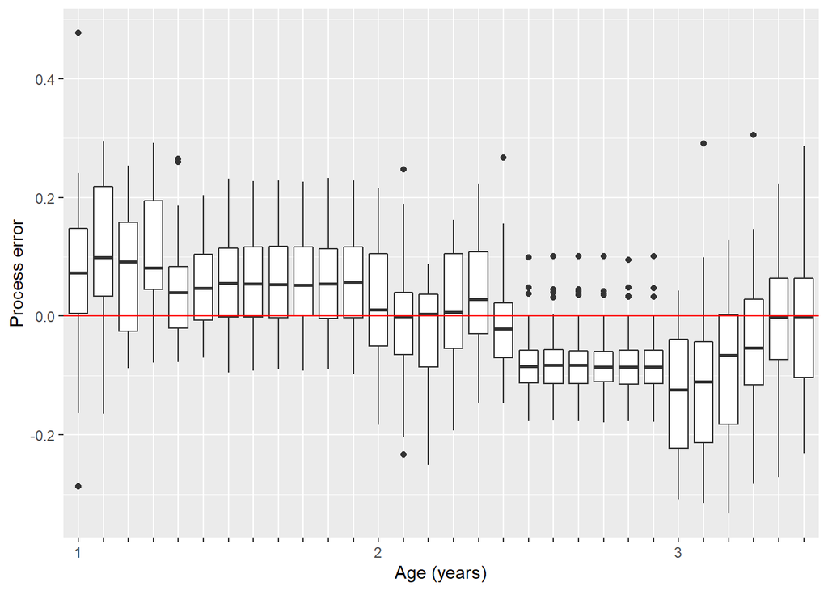

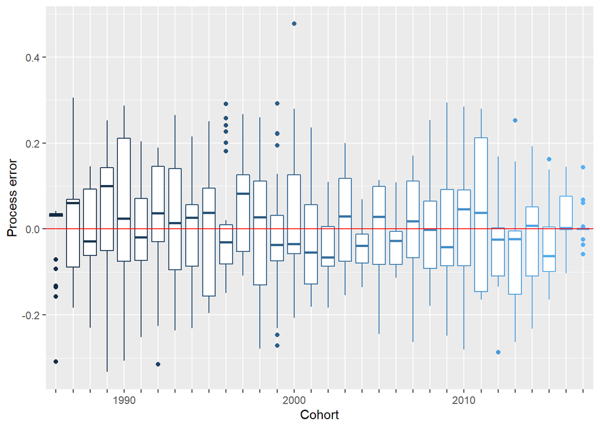

## Next steps:

1. Does anyone have any thoughts on why faster growth during the first year and slower growth especially during the second winter and age 3 are getting shunted into random effects? Is it important to fix? I’m not weighting anything by sample size. Maybe age 3 mean lengths are unreliable and need to be down-weighted? I recall that I tried doing that and the results were wonky for some reason. Maybe the data are just not informative enough for such a data-hungry state-space model?
2. Compare with condition index (have data), look at possible oceanographic and density-related correlates with growth and condition?